# 05_Basic_Models

## Supervised

Lastly, we’ll use both lipid and protein datasets simultaneously in a supervised model, predicting the outcome variable. The model produced here is quite lackluster, such that the sample groups are clustering together across both datasets. This indicates that there is still large amounts of noise in the system which we will be needing to remove.

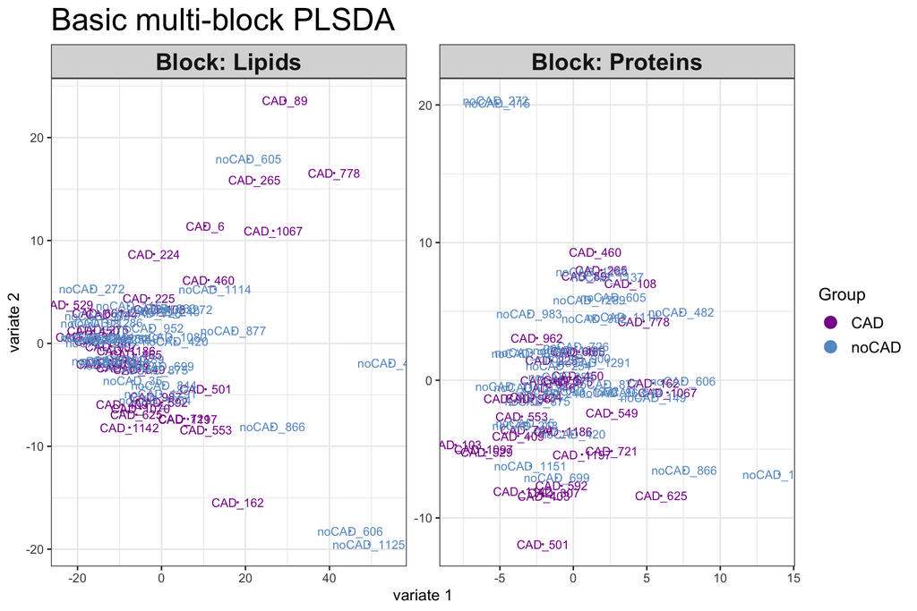

```r
lipidProteinPLSDA <- block.plsda(list(Lipids = data$dfs$lipids,
                                      Proteins = data$dfs$proteins),
                                 data$samples$group)

plotIndiv(lipidProteinPLSDA,
          ind.names= data$samples$names,
          group = data$samples$group,
          legend = TRUE,
          legend.title = 'Group',
          title = "Basic multi-block PLSDA",
          col = Group.Palette)
```

Interestingly, the features cluster well within each dataset when looking at their correlation to the first and second components. While there is still noise, it seems that there is a large degree of orthogonality to our two datasets which is very encouraging to see.

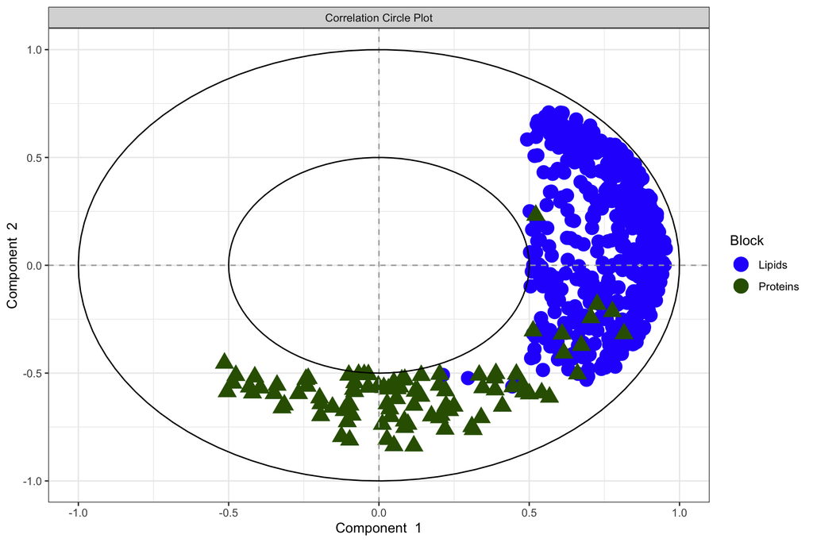

```r
plotVar(lipidProteinPLSDA,
        cutoff = 0.5,
        var.names = FALSE,
        legend = T,
        pch = c(16, 17),
        col = Block.Palette)
```